# R Notebook

Mike Kozlowski, HDS

Ebola outbreak data set

Data from a predicted data set

https://epirhandbook.com/en/missing-data.html

Making use of the nanair package

```r
require("VIM")
require("validate")
require('robustbase')
require("lmtest")
require("rio")
infile="C:\\Users\\Mike\\Documents\\DAT511\\5-3 class\\linelist_cleaned.rds"

linelist=import(infile)
```

This is a datase from a simulated ebola infection event, it is in a slightly odd data format, an rds or r data set file

We will look at it using the tools in VIM, but also another package called naniar, a tool to analyze Na values

What do we have in the data:

```r
head(linelist)
```

|  | case_id | generation | date_infection | date_onset | date_hospitalisation | date_outcome | outcome | gender | age | age_unit | age_years | age_cat | age_cat5 | hospital | lon | lat | infector | source | wt_kg | ht_cm | ct_blood | fever | chills | cough | aches | vomit | temp | time_admission | bmi | … |
| --- | --- | --- | --- | --- | --- | --- | --- | --- | --- | --- | --- | --- | --- | --- | --- | --- | --- | --- | --- | --- | --- | --- | --- | --- | --- | --- | --- | --- | --- | --- |
| 1 | 5fe599 | 4 | 2014-05-08 | 2014-05-13 | 2014-05-15 |  | NA | m | 2 | years | 2 | 0-4 | 0-4 | Other | -13.21574 | 8.468973 | f547d6 | other | 27 | 48 | 22 | no | no | yes | no | yes | 36.8 | NA | 117.18750 | … |
| 2 | 8689b7 | 4 |  | 2014-05-13 | 2014-05-14 | 2014-05-18 | Recover | f | 3 | years | 3 | 0-4 | 0-4 | Missing | -13.21523 | 8.451719 | NA | NA | 25 | 59 | 22 | NA | NA | NA | NA | NA | 36.9 | 09:36 | 71.81844 | … |
| 3 | 11f8ea | 2 |  | 2014-05-16 | 2014-05-18 | 2014-05-30 | Recover | m | 56 | years | 56 | 50-69 | 55-59 | St. Mark's Maternity Hospital (SMMH) | -13.21291 | 8.464817 | NA | NA | 91 | 238 | 21 | NA | NA | NA | NA | NA | 36.9 | 16:48 | 16.06525 | … |
| 4 | b8812a | 3 | 2014-05-04 | 2014-05-18 | 2014-05-20 |  | NA | f | 18 | years | 18 | 15-19 | 15-19 | Port Hospital | -13.23637 | 8.475476 | f90f5f | other | 41 | 135 | 23 | no | no | no | no | no | 36.8 | 11:22 | 22.49657 | … |
| 5 | 893f25 | 3 | 2014-05-18 | 2014-05-21 | 2014-05-22 | 2014-05-29 | Recover | m | 3 | years | 3 | 0-4 | 0-4 | Military Hospital | -13.22286 | 8.460824 | 11f8ea | other | 36 | 71 | 23 | no | no | yes | no | yes | 36.9 | 12:60 | 71.41440 | … |
| 6 | be99c8 | 3 | 2014-05-03 | 2014-05-22 | 2014-05-23 | 2014-05-24 | Recover | f | 16 | years | 16 | 15-19 | 15-19 | Port Hospital | -13.22263 | 8.461831 | aec8ec | other | 56 | 116 | 21 | no | no | yes | no | yes | 37.6 | 14:13 | 41.61712 | … |

```r
summary(linelist)
```

```
##    case_id            generation    date_infection         date_onset
##  Length:5888        Min.   : 0.00   Min.   :2014-03-19   Min.   :2014-04-07
##  Class :character   1st Qu.:13.00   1st Qu.:2014-09-06   1st Qu.:2014-09-16
##  Mode  :character   Median :16.00   Median :2014-10-11   Median :2014-10-23
##                     Mean   :16.56   Mean   :2014-10-22   Mean   :2014-11-03
##                     3rd Qu.:20.00   3rd Qu.:2014-12-05   3rd Qu.:2014-12-19
##                     Max.   :37.00   Max.   :2015-04-27   Max.   :2015-04-30
##                                     NA's   :2087         NA's   :256
##  date_hospitalisation  date_outcome          outcome
##  Min.   :2014-04-17   Min.   :2014-04-19   Length:5888
##  1st Qu.:2014-09-19   1st Qu.:2014-09-26   Class :character
##  Median :2014-10-23   Median :2014-11-01   Mode  :character
##  Mean   :2014-11-03   Mean   :2014-11-12
##  3rd Qu.:2014-12-17   3rd Qu.:2014-12-28
##  Max.   :2015-04-30   Max.   :2015-06-04
##                       NA's   :936
##     gender               age          age_unit           age_years
##  Length:5888        Min.   : 0.00   Length:5888        Min.   : 0.00
##  Class :character   1st Qu.: 6.00   Class :character   1st Qu.: 6.00
##  Mode  :character   Median :13.00   Mode  :character   Median :13.00
##                     Mean   :16.07                      Mean   :16.02
##                     3rd Qu.:23.00                      3rd Qu.:23.00
##                     Max.   :84.00                      Max.   :84.00
##                     NA's   :86                         NA's   :86
##     age_cat        age_cat5      hospital              lon
##  0-4    :1095   0-4    :1095   Length:5888        Min.   :-13.27
##  5-9    :1095   5-9    :1095   Class :character   1st Qu.:-13.25
##  20-29  :1073   10-14  : 941   Mode  :character   Median :-13.23
##  10-14  : 941   15-19  : 743                      Mean   :-13.23
##  30-49  : 754   20-24  : 638                      3rd Qu.:-13.22
##  (Other): 844   (Other):1290                      Max.   :-13.21
##  NA's   :  86   NA's   :  86
##       lat          infector            source              wt_kg
##  Min.   :8.446   Length:5888        Length:5888        Min.   :-11.00
##  1st Qu.:8.461   Class :character   Class :character   1st Qu.: 41.00
##  Median :8.469   Mode  :character   Mode  :character   Median : 54.00
##  Mean   :8.470                                         Mean   : 52.64
##  3rd Qu.:8.480                                         3rd Qu.: 66.00
##  Max.   :8.492                                         Max.   :111.00
##
```

[output cut: 9 more lines]

```
##  Length:5888        Length:5888        Length:5888        Min.   :35.20
##  Class :character   Class :character   Class :character   1st Qu.:38.20
##  Mode  :character   Mode  :character   Mode  :character   Median :38.80
##                                                           Mean   :38.56
##                                                           3rd Qu.:39.20
##                                                           Max.   :40.80
##                                                           NA's   :149
##  time_admission          bmi           days_onset_hosp
##  Length:5888        Min.   :-1200.00   Min.   : 0.000
##  Class :character   1st Qu.:   24.56   1st Qu.: 1.000
##  Mode  :character   Median :   32.12   Median : 1.000
##                     Mean   :   46.89   Mean   : 2.059
##                     3rd Qu.:   50.01   3rd Qu.: 3.000
##                     Max.   : 1250.00   Max.   :22.000
##                                        NA's   :256
```

Just to simplify things a bit, let’s drop some data

time_admission, lon, lat, case_id -these don’t mean much to us

```r
linelist=linelist[, !(names(linelist) %in% c("time_admission","lon","lat","case_id"))]
```

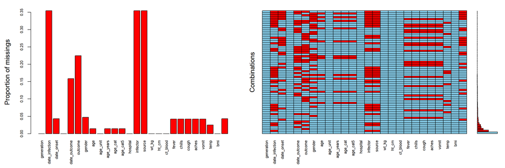

```r
aggr(linelist,cex.axis=0.7)
```

#Question/Action

What are the top five most often missing items in this data set?

The top five most often missing items are date_infeection, date_outcome, outcome, infector, and source.

What are the top five most common combinations of missing items?

The nanair package has an alternative way to show missing data information

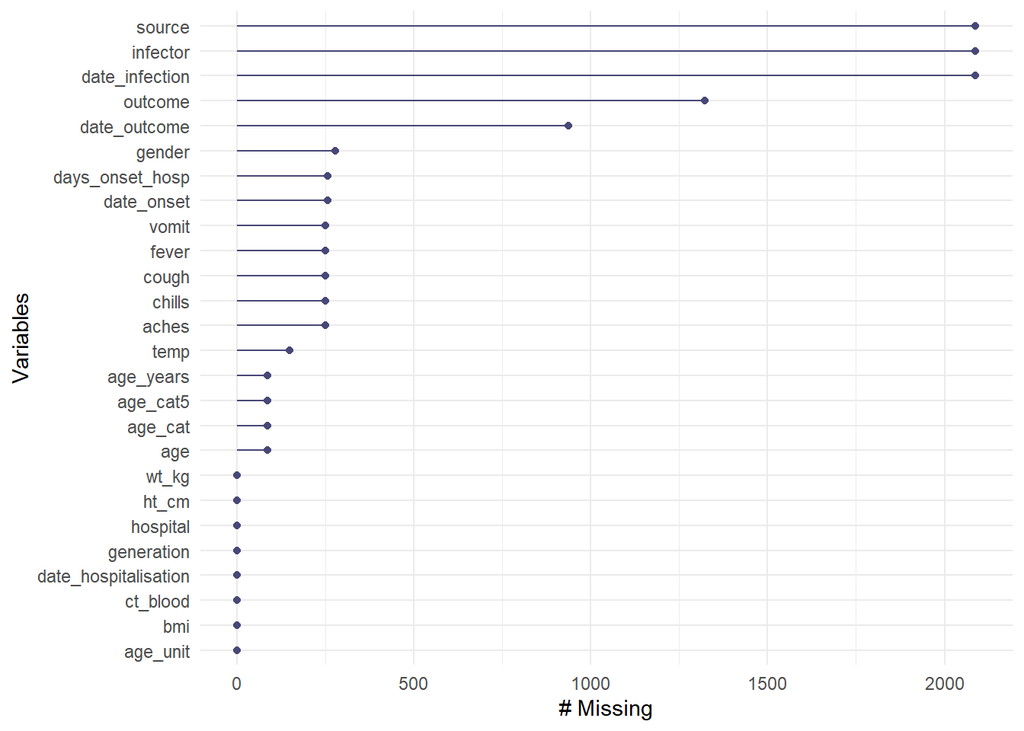

```r
require(ggplot2)
require(tidyverse)
require(naniar)
gg_miss_var(linelist)
```

# Using VIM to look at patterns or shifts in data due to missing values

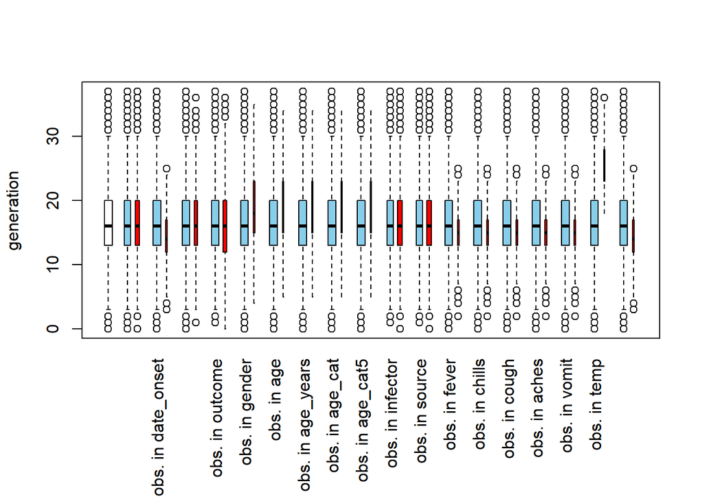

```r
#windows()
VIM::pbox(linelist)
```

# Question/Action

What variable in this plot shows a large shift associated with missing data values?

Describe what appears to be happening, and whether or not this makes sense.

We can look at a margin plot of age in years and temp

Here is the VIM version

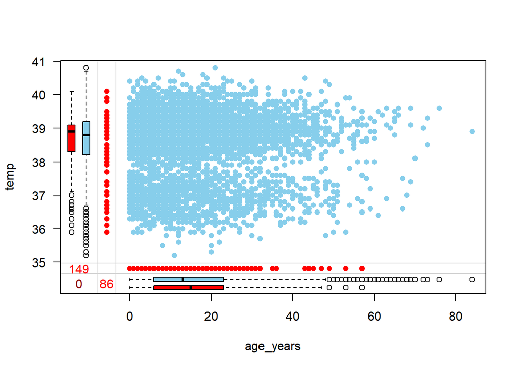

```r
mydat=linelist[,c("age_years","temp")]
VIM::marginplot(mydat,las=1,pch=16)
```

Here is the nanair version of the same plot

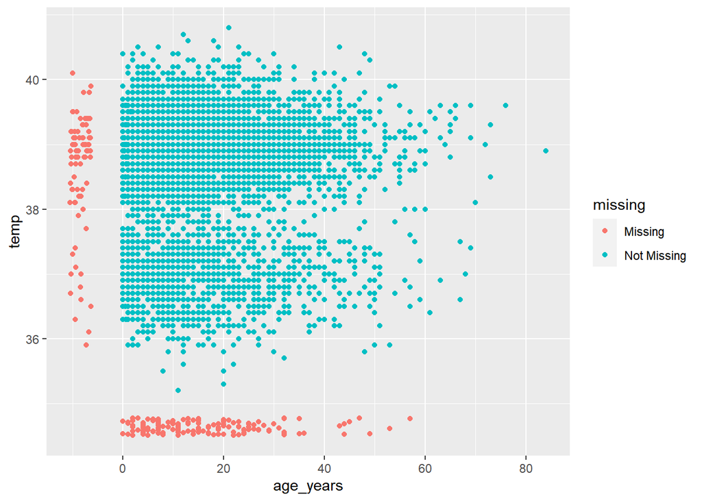

```r
ggplot(
  data = linelist,
  mapping = aes(x = age_years, y = temp)) +
  geom_miss_point()
```

#Question/Action

Based on your answer to the last question, about which variable seems to show the largest shift associated with missing data, produce both styles of margin plots as a way of investigating the relationship you saw earlier.

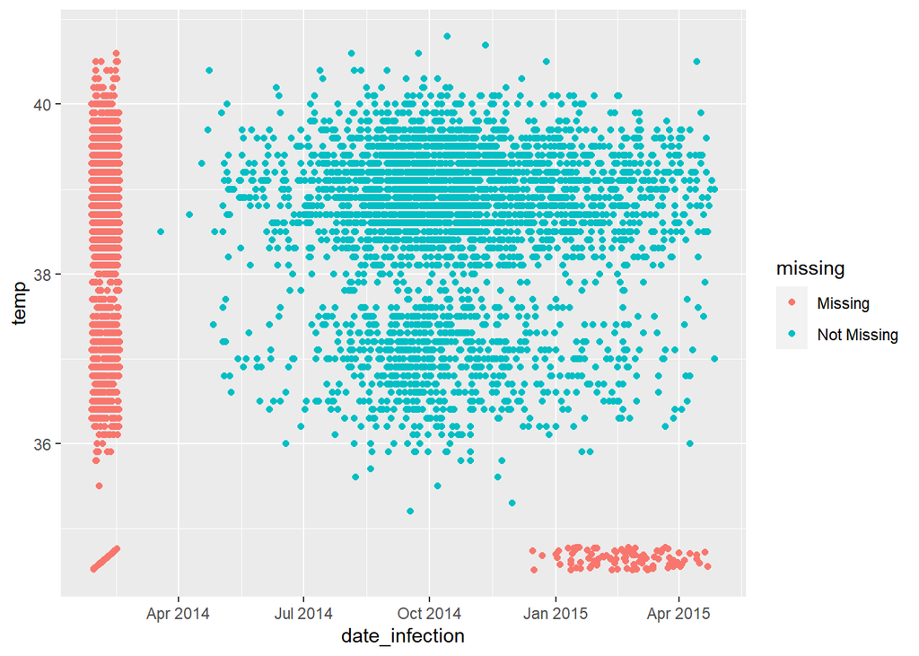

```r
ggplot(
  data = linelist,
  mapping = aes(x = date_infection, y = temp)) +
  geom_miss_point()
```

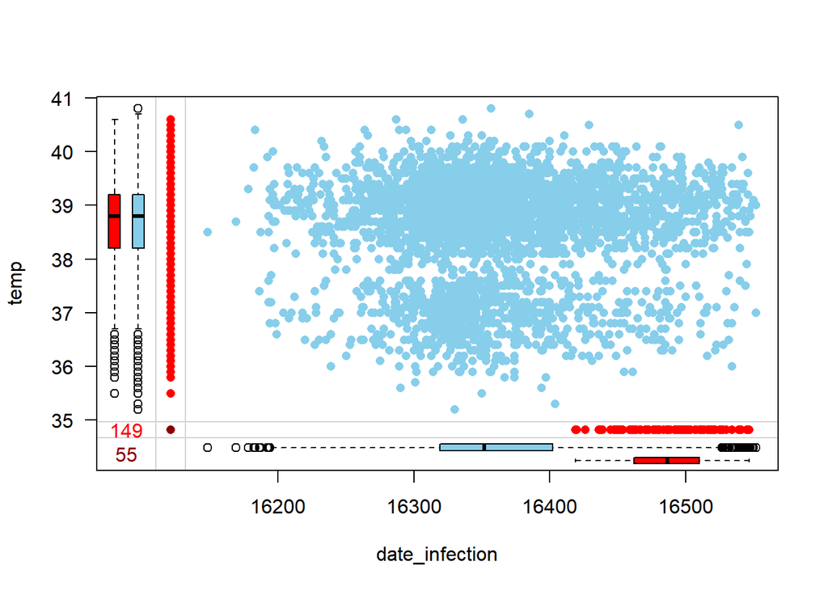

```r
mydat=linelist[,c("date_infection","temp")]
VIM::marginplot(mydat,las=1,pch=16)
```

We use a nanair plot of missing rates as a function of a categorical, such as outcome

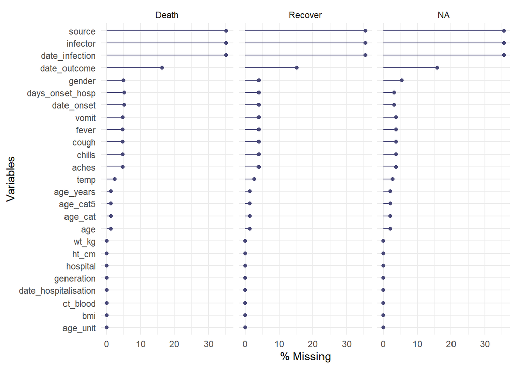

```r
linelist %>%
  gg_miss_var(show_pct = TRUE, facet = outcome)
```

# Question/Action

Use this type of faceting by a factor to look at another factor that might related to missing values

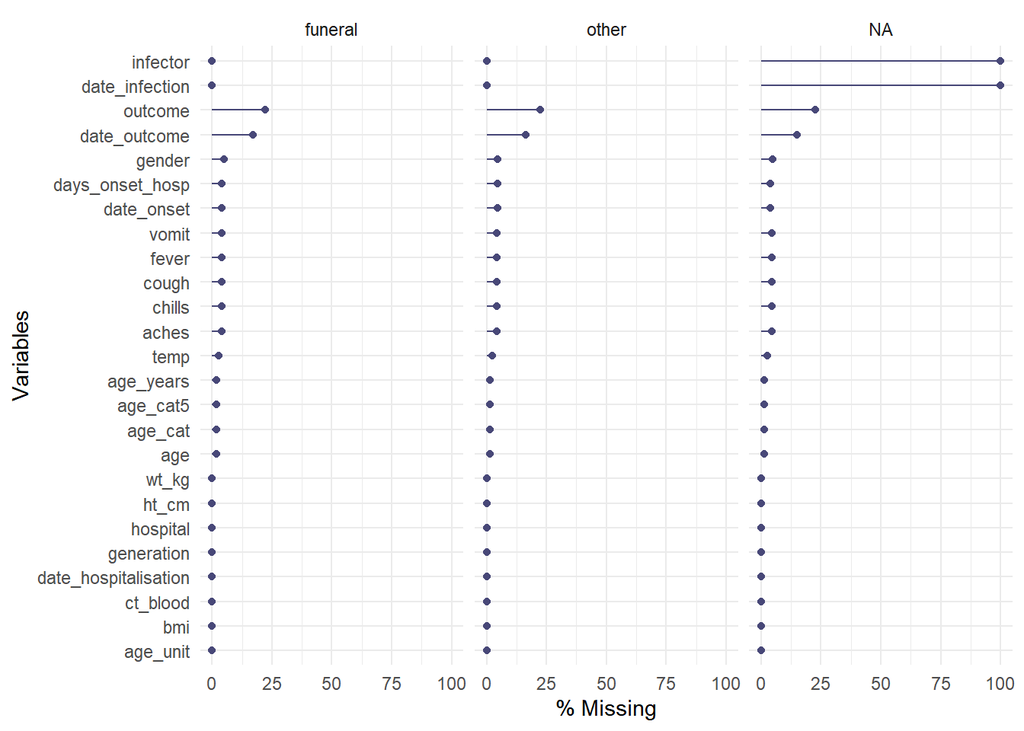

```r
linelist %>%
  gg_miss_var(show_pct = TRUE, facet = source)
```

#visualizing where in the data set there are missing values

The visdat function can show us the patterns of missing data and the data types

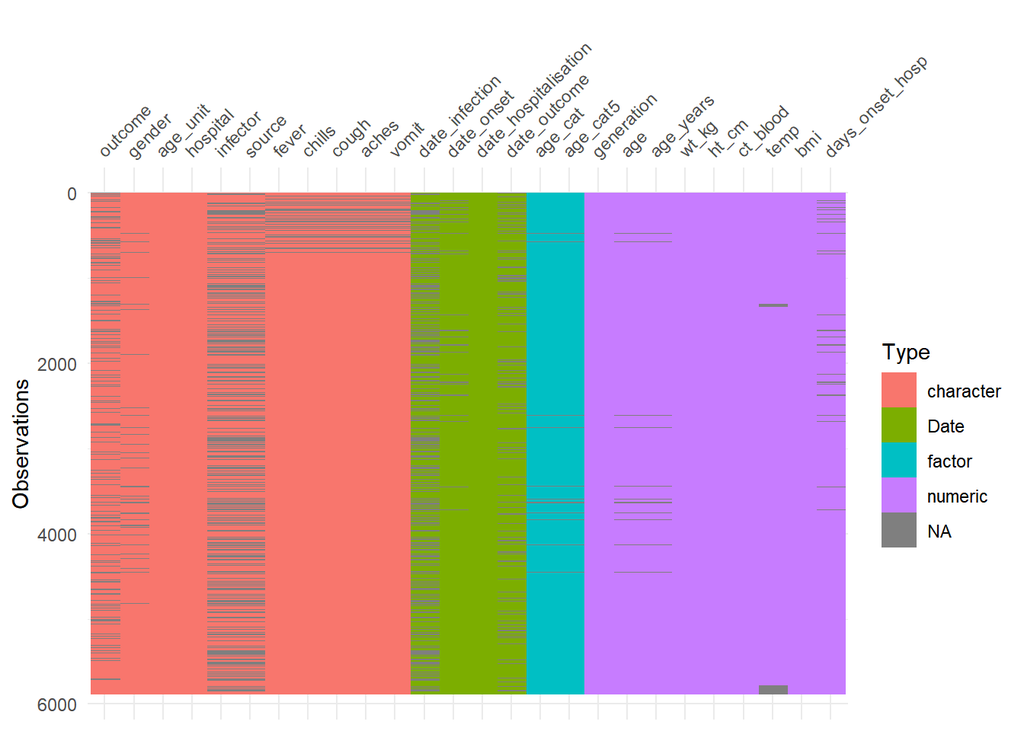

```r
require(visdat)
vis_dat(linelist)
```

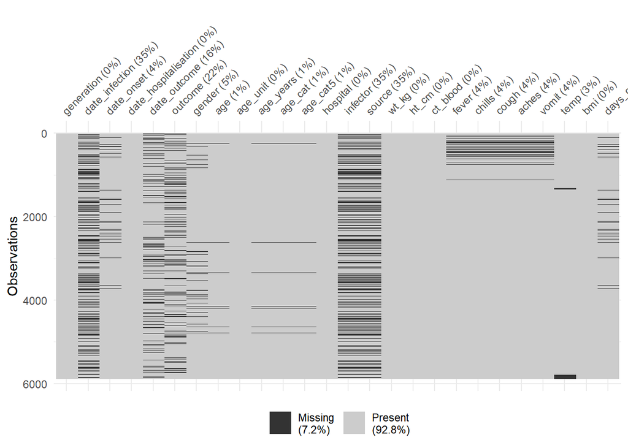

```r
vis_miss(linelist)
```

# Question/Action

Sort the data set by some value, maybe age, date of admission, or some other variable.

Then send the ordered data set results into vis_miss so the missing information is ordered- do you see any patterns?

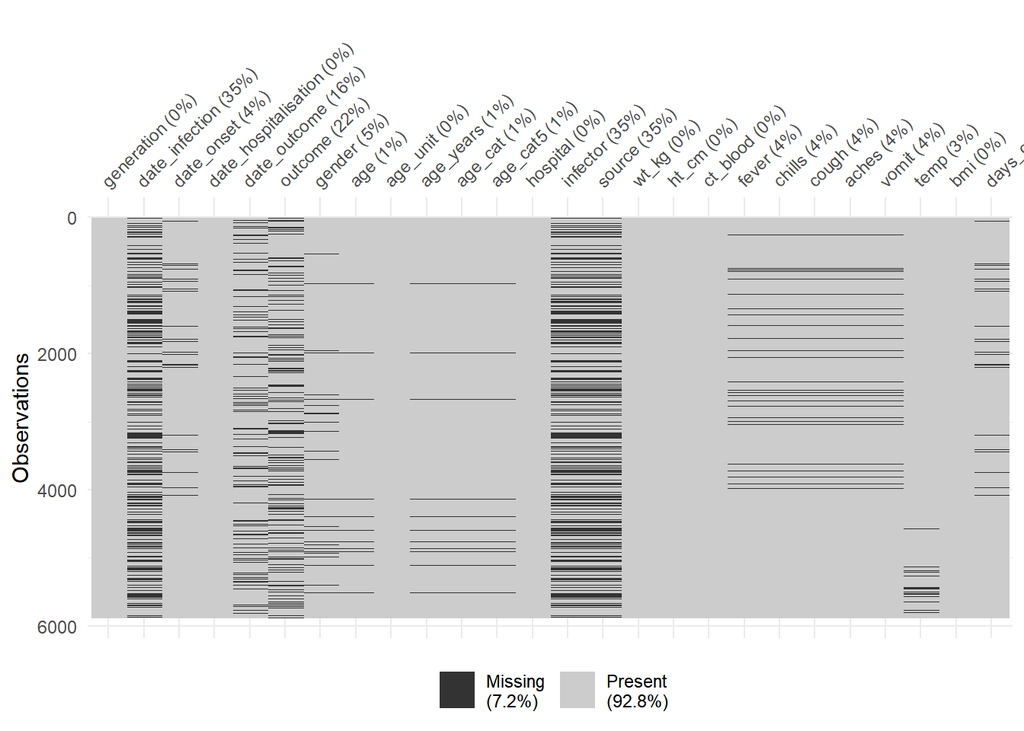

```r
sortedData <- linelist[order(linelist$date_hospitalisation),]
vis_miss(sortedData)
```

It appears that infector, source, and date_infection seem to match when data is missing, as well as fever, cough, aches, and vomit.

We can heatmpa the rates of missing information by some factor as well

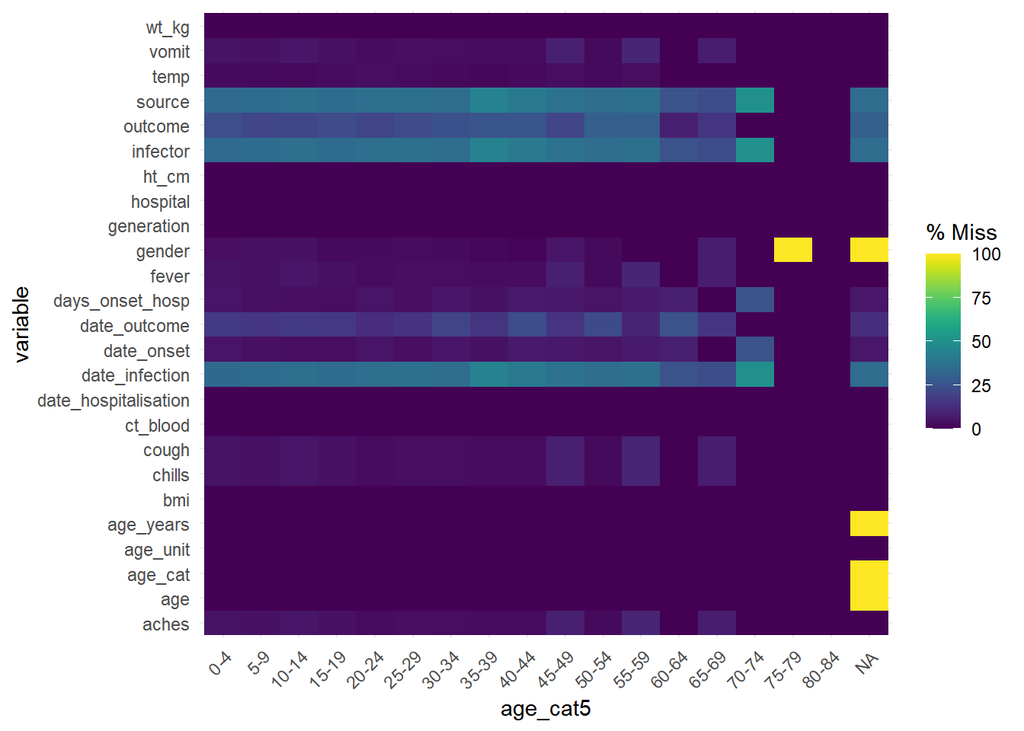

```r
gg_miss_fct(linelist, age_cat5)
```

We can create a “shadowed” data set that has columns that indicate if there are missing values in other columns

```r
shadowed_linelist <- linelist %>%
  bind_shadow()

names(shadowed_linelist)
```

```
##  [1] "generation"              "date_infection"
##  [3] "date_onset"              "date_hospitalisation"
##  [5] "date_outcome"            "outcome"
##  [7] "gender"                  "age"
##  [9] "age_unit"                "age_years"
## [11] "age_cat"                 "age_cat5"
## [13] "hospital"                "infector"
## [15] "source"                  "wt_kg"
## [17] "ht_cm"                   "ct_blood"
## [19] "fever"                   "chills"
## [21] "cough"                   "aches"
## [23] "vomit"                   "temp"
## [25] "bmi"                     "days_onset_hosp"
## [27] "generation_NA"           "date_infection_NA"
## [29] "date_onset_NA"           "date_hospitalisation_NA"
## [31] "date_outcome_NA"         "outcome_NA"
## [33] "gender_NA"               "age_NA"
## [35] "age_unit_NA"             "age_years_NA"
## [37] "age_cat_NA"              "age_cat5_NA"
## [39] "hospital_NA"             "infector_NA"
## [41] "source_NA"               "wt_kg_NA"
## [43] "ht_cm_NA"                "ct_blood_NA"
## [45] "fever_NA"                "chills_NA"
## [47] "cough_NA"                "aches_NA"
## [49] "vomit_NA"                "temp_NA"
## [51] "bmi_NA"                  "days_onset_hosp_NA"
```

We can then create histograms or time series of the distributions of missing data

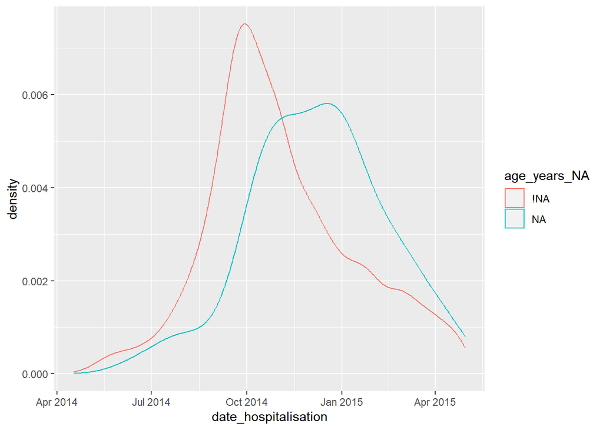

```r
ggplot(data = shadowed_linelist,          # data frame with shadow columns
  mapping = aes(x = date_hospitalisation, # numeric or date column
                colour = age_years_NA)) + # shadow column of interest
  geom_density()                          # plots the density curves
```

Looking at where in a distribution the data is missing

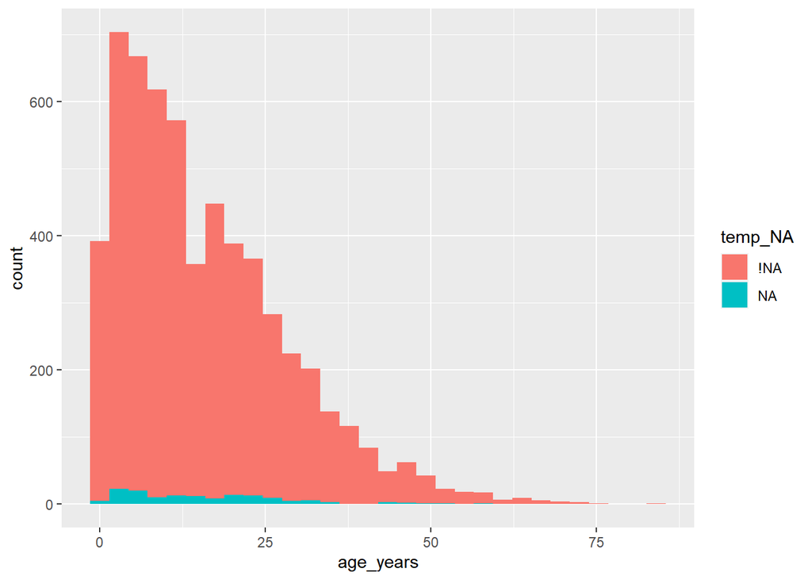

```r
ggplot(data = shadowed_linelist, aes(x=age_years,fill=temp_NA))+geom_histogram()
```

#Modelling missingness

We can build a model to predict when data will be missing

The function add_prop_miss adds a column to the data that computes the proportion of missing data on the line and adds that to the last column

```r
linelist2=add_prop_miss(linelist)
head(linelist2)
```

|  | generation | date_infection | date_onset | date_hospitalisation | date_outcome | outcome | gender | age | age_unit | age_years | age_cat | age_cat5 | hospital | infector | source | wt_kg | ht_cm | ct_blood | fever | chills | cough | aches | vomit | temp | bmi | days_onset_hosp | prop_miss_all |
| --- | --- | --- | --- | --- | --- | --- | --- | --- | --- | --- | --- | --- | --- | --- | --- | --- | --- | --- | --- | --- | --- | --- | --- | --- | --- | --- | --- |
| 1 | 4 | 2014-05-08 | 2014-05-13 | 2014-05-15 |  | NA | m | 2 | years | 2 | 0-4 | 0-4 | Other | f547d6 | other | 27 | 48 | 22 | no | no | yes | no | yes | 36.8 | 117.18750 | 2 | 0.07692308 |
| 2 | 4 |  | 2014-05-13 | 2014-05-14 | 2014-05-18 | Recover | f | 3 | years | 3 | 0-4 | 0-4 | Missing | NA | NA | 25 | 59 | 22 | NA | NA | NA | NA | NA | 36.9 | 71.81844 | 1 | 0.30769231 |
| 3 | 2 |  | 2014-05-16 | 2014-05-18 | 2014-05-30 | Recover | m | 56 | years | 56 | 50-69 | 55-59 | St. Mark's Maternity Hospital (SMMH) | NA | NA | 91 | 238 | 21 | NA | NA | NA | NA | NA | 36.9 | 16.06525 | 2 | 0.30769231 |
| 4 | 3 | 2014-05-04 | 2014-05-18 | 2014-05-20 |  | NA | f | 18 | years | 18 | 15-19 | 15-19 | Port Hospital | f90f5f | other | 41 | 135 | 23 | no | no | no | no | no | 36.8 | 22.49657 | 2 | 0.07692308 |
| 5 | 3 | 2014-05-18 | 2014-05-21 | 2014-05-22 | 2014-05-29 | Recover | m | 3 | years | 3 | 0-4 | 0-4 | Military Hospital | 11f8ea | other | 36 | 71 | 23 | no | no | yes | no | yes | 36.9 | 71.41440 | 1 | 0.00000000 |
| 6 | 3 | 2014-05-03 | 2014-05-22 | 2014-05-23 | 2014-05-24 | Recover | f | 16 | years | 16 | 15-19 | 15-19 | Port Hospital | aec8ec | other | 56 | 116 | 21 | no | no | yes | no | yes | 37.6 | 41.61712 | 1 | 0.00000000 |

It is then possible to build a predictive model (a regression tree) that will predict the value of prop_miss_all, in other words the proportion of missing data based on the other variables

In the discussion of imputing, we saw how predictive models could be used to impute missing values.

In this application, we are using the predictive model to predict when a particular row in the data frame will have missing information.

Models such as regression trees can tell us which variables are being used to make predictions, in a regression tree these are called the “importance” value of each predictor variable. We fit a regression tree to the model and then use the importance values to determine which of the predictors is informative about when data is likely to be missing. Then we can go back to the visual methods to understand what the relationship is.

Below, we fit a regression tree to the data to predict the proportion missing variable, using all the other variables, and then look at the summary() of the model to find the importance values. The summary of this model is quite long, we have to dig through it a bit to find the importances.

```r
require("rpart")
rmodel=rpart(prop_miss_all~., linelist2)
```

The model importance values tell us which variables are effective at predicting missing data

```r
summary(rmodel)
```

```
## Call:
## rpart(formula = prop_miss_all ~ ., data = linelist2)
##   n= 5888
##
##           CP nsplit rel error   xerror       xstd
## 1 0.03849279      0 1.0000000 1.000281 0.02338594
## 2 0.03351233      2 0.9230144 1.086485 0.02568671
## 3 0.02759585      3 0.8895021 1.051708 0.02463689
## 4 0.01602697      5 0.8343104 1.011147 0.02217159
## 5 0.01289415      6 0.8182834 1.007242 0.02221775
## 6 0.01000000      7 0.8053893 1.009549 0.02238935
##
## Variable importance
##             infector                 temp                fever
##                   79                   12                    5
##               source       date_infection             hospital
##                    1                    1                    1
## date_hospitalisation
##                    1
##
## Node number 1: 5888 observations,    complexity param=0.03849279
##   mean=0.07218071, MSE=0.00578312
##   left son=2 (5373 obs) right son=3 (515 obs)
##   Primary splits:
##       infector             splits as  LLLLLLLRLLLLLLLRLLLLLLLRRLLLLLLRLLLLRLLLLLLLLLLLLRLLLLLRRLLL…, improve=0.135474500, (2088 missing)
##       temp                 < 37.95     to the right, improve=0.042394820, (149 missing)
##       ct_blood             < 20.5      to the left,  improve=0.006225116, (0 missing)
##       days_onset_hosp      < 2.5       to the right, improve=0.003747335, (256 missing)
##       date_hospitalisation < 16373.5   to the right, improve=0.002134539, (0 missing)
##
## Node number 2: 5373 observations,    complexity param=0.03351233
##   mean=0.06766024, MSE=0.00545252
##   left son=4 (4191 obs) right son=5 (1182 obs)
##   Primary splits:
##       infector     splits as  LLRLLLL-LLLLRLL-LRLRLRL--RRLRLL-LRLR-RLLRLLLRLLLR-RLRLL--LRLRLL-RRLLLLLLRLLLLLLLLLL-LLLRLRLLLLLLRRLLL-RRR-LRRL-L-LLRLLLLRRRLLLLRR--L--RLLRLLLLL-RLLL-LRRLLL-LLLRLLLLRLLRR-LLRLLL-R-L-LRL-LRLRLLLLLLLRLRRRRLRLLLLLRLLLLLRL-LRRL-LLLLLRLRRLLRLLRLLLRLLLLRLRLLLRLR-LLL--LRLLRL…
##       temp         < 37.95     to the right, improve=0.017539360, (133 missing)
##       ct_blood     < 20.5      to the left,  improve=0.002614700, (0 missing)
##       age_cat5     splits as  LLLLLLLRRRRRLLRLL-, improve=0.001979148, (34 missing)
##       date_outcome < 16382.5   to the right, improve=0.001581080, (774 missing)
##   Surrogate splits:
```

[output cut: 82 more lines]

```
##       hospital             splits as  RRLLLR, agree=0.614, adj=0.136, (0 split)
##       date_hospitalisation < 16353     to the right, agree=0.606, adj=0.119, (0 split)
##       age_cat5             splits as  LRRLLLRLLL--LL----, agree=0.598, adj=0.102, (0 split)
##
## Node number 16: 2862 observations
##   mean=0.07737999, MSE=0.005414551
##
## Node number 17: 461 observations
##   mean=0.02002336, MSE=0.0004077007
##
## Node number 26: 73 observations
##   mean=0.09325606, MSE=0.004819559
##
## Node number 27: 59 observations
##   mean=0.2092568, MSE=0.000515053
```

#Looking at this summary,

Variable importance infector temp fever source 79 12 5 1 date_infection hospital date_hospitalisation 1 1 1

the term that predicts missing data most effectively are the infector and temp values

# Looking at the correlation of missing entries

We have the dataframe shadowed_linelist which has columns added to indicate whether or not the corresponding variables are missing or not. We could look at this to see the extent to which missing values are correlated with other missing values

```r
colnames(shadowed_linelist)
```

```
##  [1] "generation"              "date_infection"
##  [3] "date_onset"              "date_hospitalisation"
##  [5] "date_outcome"            "outcome"
##  [7] "gender"                  "age"
##  [9] "age_unit"                "age_years"
## [11] "age_cat"                 "age_cat5"
## [13] "hospital"                "infector"
## [15] "source"                  "wt_kg"
## [17] "ht_cm"                   "ct_blood"
## [19] "fever"                   "chills"
## [21] "cough"                   "aches"
## [23] "vomit"                   "temp"
## [25] "bmi"                     "days_onset_hosp"
## [27] "generation_NA"           "date_infection_NA"
## [29] "date_onset_NA"           "date_hospitalisation_NA"
## [31] "date_outcome_NA"         "outcome_NA"
## [33] "gender_NA"               "age_NA"
## [35] "age_unit_NA"             "age_years_NA"
## [37] "age_cat_NA"              "age_cat5_NA"
## [39] "hospital_NA"             "infector_NA"
## [41] "source_NA"               "wt_kg_NA"
## [43] "ht_cm_NA"                "ct_blood_NA"
## [45] "fever_NA"                "chills_NA"
## [47] "cough_NA"                "aches_NA"
## [49] "vomit_NA"                "temp_NA"
## [51] "bmi_NA"                  "days_onset_hosp_NA"
```

In the shadowed_linelist, columns 27-52 have the counts of the missing data, lines 1-26 have the data itself

What we want to do is compute the correlation matrix of the NA count columns and show it as a heatmap

This allows us to see the extent to which missing entries are paired with other missing values

```r
require("reshape2")
#force the na values to be O and the non-na to be 1

nacor=cor((shadowed_linelist[,27:52]=="!NA")*1.0)
```

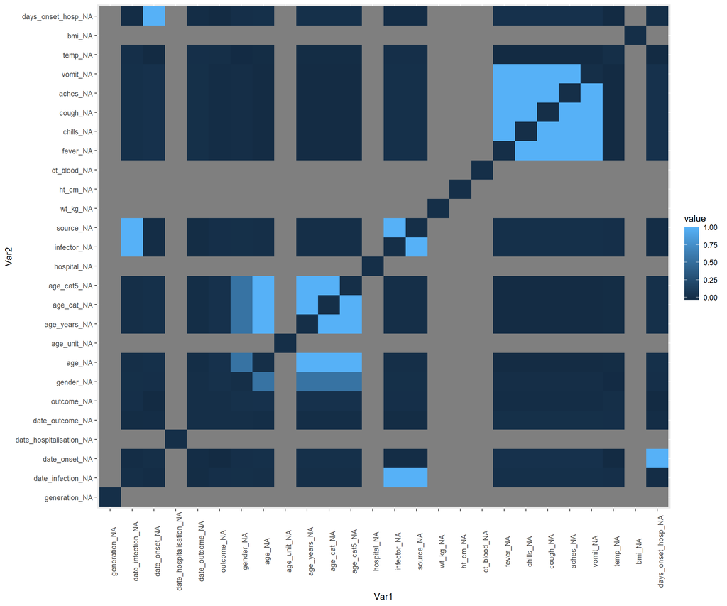

```r
# replace all the values on the diagonal with zeros
# the diagonals are all ones,  and this distorts the heatmap

diag(nacor)<-0

# melted version of the matrix of data, use this in ggplot to create a heatmap
melted_nacor=melt(nacor)

ggplot(data=melted_nacor,aes(x=Var1,y=Var2,fill=value))+geom_tile()+theme(axis.text.x=element_text(angle=90))
```

# Question/Action

What are the high correlation pairs or groups in the above diagram?

Do these make sense? Are they likely to have a common cause? Why?

These definitely make sense - if you do not know the infector or source, you’re unlikely to know when the person was infected, as they lack that information. Age being correlated to age related fields all make sense, source with infector being correlated is logical as well, and if the disease is likely to have a very common base of symptoms, it would make sense that patients are expected to show all symptoms, and it makes sense that patients that are missing some symptoms are missing others.